# Virginia Unemployment

An exploration of Virginia Unemployment. This was inspired by an r-Blogger post on Georgia Unemployment.

This is the articel which inspired me to explroe this dataset. The code below is mashup of the article’s code along with additions and subtractions to explore the data differently. https://www.r-bloggers.com/state-unemployment-claims/

Below is some data cleaning code, where we pull data from FRED, ann then shows the first and last rows which gives a good view of the timeframe of the data.

```
# A tibble: 2 x 3
  symbol    date       claims
  <chr>     <date>      <int>
1 VAICLAIMS 1999-01-02   9361
2 VAICLAIMS 2020-04-04 147369
```

Here we can look at the weeks with the msot overall claims. Unsurprisingly we find the latest reports at the top. COVID-19 holds the record for the most unemployment claims. Coming in 4th is the first of the year in 2009, likely due to the 2008 financial crisis.

```
# A tibble: 5 x 2
  date       claims
  <date>      <int>
1 2020-04-04 147369
2 2020-03-28 112497
3 2020-03-21  46277
4 2009-01-10  21862
5 2003-01-11  19814
```

Also shown in column form:

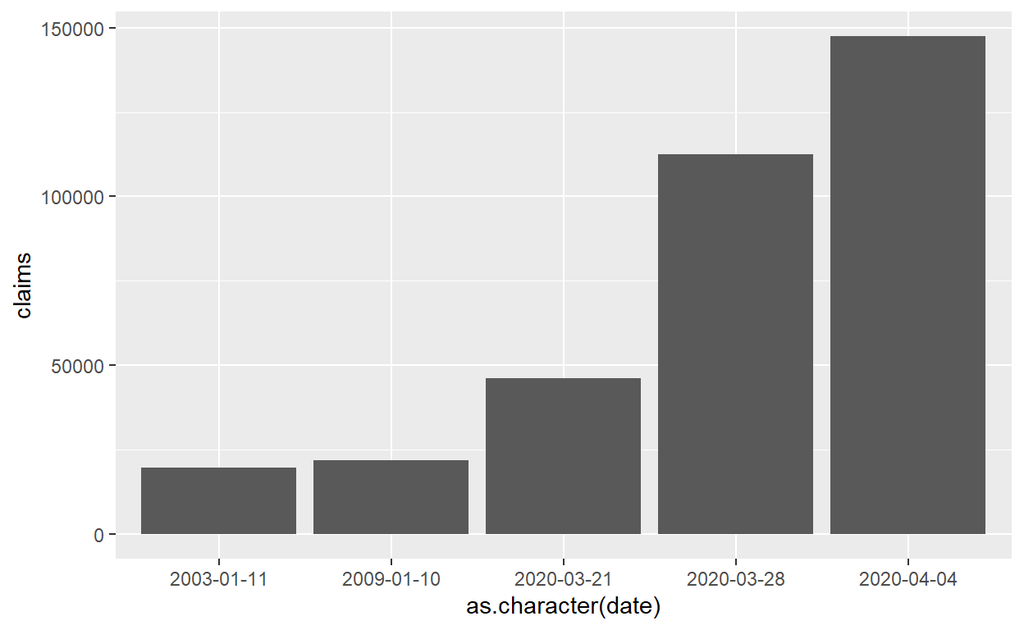

We can also look at the claims numbers over the years through a line chart

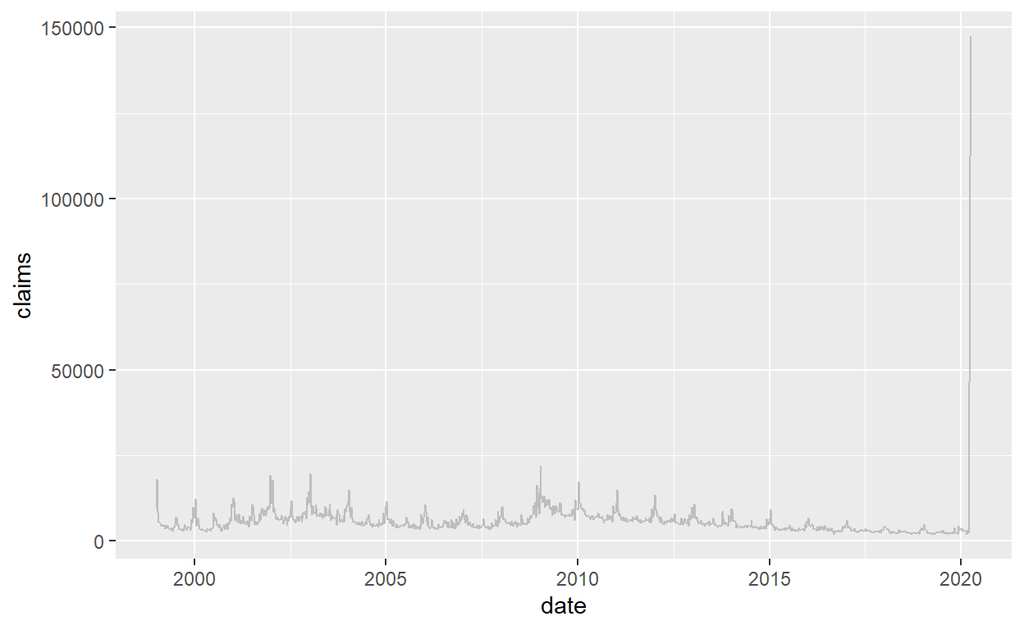

To dig deeper we need to use the mutate function to have greater grouping functionality of the dates variable. Here we create attributes for each year, month, and week. We don’t create a seperate value for day as all of the reports are coded as coming in on a saturday.

```
# A tibble: 1 x 6
  symbol    date       claims  year month  week
  <chr>     <date>      <int> <dbl> <ord> <dbl>
1 VAICLAIMS 1999-01-02   9361  1999 Jan       1
```